# act_report

## Report: Which day of the week records most retweets on WeRateDogs?

## Introduction

> Many would argue, a dog is a man's most loyal companion. Little wonder, dog lovers around the globe have learnt to care for their pets and pay them such attention, most have even become functional parts of many families. It is no surprise then that, a dog owner gets so curious, s/he wants to know how his/her dog compares against others of same/different breeds.

> Enter WeRateDogs. WeRateDogs is a Twitter account that rates people's dogs with a humorous comment about the dog. These ratings almost always have a denominator of 10. The numerators, though? Almost always greater than 10. 11/10, 12/10, 13/10, etc. Why? Because "they're good dogs Brent." WeRateDogs has over 4 million followers and has received international media coverage.

> The sole purpose of this project is to communicate the insights and display the visualization(s) produced from our wrangled data(**main_copy**). The WeRateDogs Twitter Archive contains basic tweet data (tweet ID, timestamp, text, etc.) for all 5000+ of their tweets as they stood on August 1st, 2017.

## Analyzing and Visualizing Data

[figure not shown]

> Every explored data yearns to tell a story and the WeRateDogs Twitter data actually tells a very profound one. In fact, the more one probes it, the more it speaks. Here, we explore and probe our data with questions and have it give us valuable insights. What insights we intend to gain:
1. Some stats: **At a glance, what information does basic stats within values of each column tell us**?
2. Correlation: **How strong or weak are the relationships between the variables**?
3. **Which day of the week had more tweets made**?

> Before we began, we quickly made a copy of our wrangled data (**main_copy**) and passed it on to **main_clean**.

### Insight 1

> Some stats: **At a glance, what information does basic stats within values of each column tell us**?

Using the **.describe()** function, we found:

> **retweet_count** and **favorite count**: Most of the dogs rated had more favorite count than retweets.

> **img_num**: The maximum number of images attached to any of the posts is 4. The minimum = 1.

### Insight 2

> Correlation: **How strong or weak are the relationships between the variables? Given 1 is maximum positive correlation and -1 is the maximum negative or inverse correlation**.

Using the **.corr()** function, we found:

> **retweet_count** and **favorite_count**: There's very strong positive correlation between retweets and favorites. The more the retweets, the higher the favorite count.

> **img_num** and **retweet_count**: There is very weak positive correlation between number of images attached to each tweet and number of retweets. The number of images attached to each tweet has little to no effect on the number of retweets.

We demonstrated this strong relationship between retweet count and favorite count with a quick pairplot.

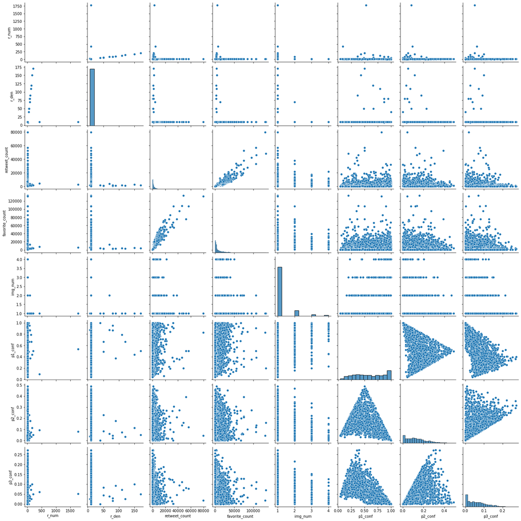

### Insight 3

> **On which day of the week were most retweets and favorites recorded?**

First, we created a new daily timed series column called "**day**" from the **timestamp** column using **dt.strftime**.

Next, we group our info by sum of retweets and favorites recorded and and days of the week those tweets were posted, all in descending order.

We found:

> **Wednesday** recorded most number of retweets and favorites.

## Visualization

[figure not shown]

> **What does our data look like when visualized? What analysis did we draw from it?**

For this, we employed a word cloud.

### Word Cloud

> Word clouds (also known as text clouds or tag clouds) work in a simple way: the more a specific word appears in a source of textual data (such as a speech, blog post, or database), the bigger and bolder it appears in the word cloud.

> A word cloud is a collection, or cluster, of words depicted in different sizes. The bigger and bolder the word appears, the more often it’s mentioned within a given text and the more important it is.

**source: https://boostlabs.com/blog/what-are-word-clouds-value-simple-visualizations/#**

To do this:

> First, we created a list from the text column.

> Next, we created a mask from an image downloaded over the internet. Our chosen image is that of a dog from the freepik website.

> Lastly, we defined a function - **generate_wordcloud(text, mask)** - to generate our word cloud plus mask.

> We called our function and voila!!!

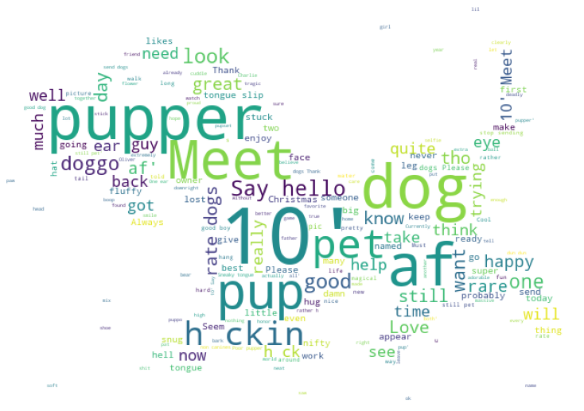

Apparently, from our word cloud:

> - There likely were more pupper stage dogs rated.
> - 10 is quite outstanding as all the ratings almost always have a denominator 10.
> - The word "Meet" also stands out as almost every tweet began with "Meet."